# Pre LiveSession 4

Richard Palmer

9/15/2019

## Part 1

### Get xml data from cloudfront.net

```r
# use XML package
# this leads to an error :-(
#rest1 <-   getURL("https://www.w3schools.com/xml/simple.xml")
#doc <- xmlParse(rest1)

restaurants_url <- "https://d396qusza40orc.cloudfront.net/getdata%2Fdata%2Frestaurants.xml"
hp <- read_html(restaurants_url)
```

Parse the html and form a dataframe with name, zipcode, and Council District

```r
hp_nameR <- html_nodes(hp,"name")
hp_zipR  <- html_nodes(hp,"zipcode")
hp_ccdR  <- html_nodes(hp,"councildistrict")
hp_name  <- html_text(hp_nameR)
hp_zip   <- html_text(hp_zipR)
hp_ccd   <- html_text(hp_ccdR)
all_restaurants <- data.frame(hp_name,hp_zip,hp_ccd)
```

Look for sushi restaurants.

```r
sushi_restaurants <- grep("sushi",all_restaurants$hp_name,ignore.case=TRUE,value=TRUE)
sushi_restaurants
```

```
## [1] "ABC SUSHI"
## [2] "ASAHI SUSHI"
## [3] "CHIU'S SUSHI JAPANESE RESTAURANT"
## [4] "CHIYO SUSHI"
## [5] "EDO SUSHI"
## [6] "GENJI SUSHI EXPRESS   (A.K.A. 600 S EXETER ST)"
## [7] "RA SUSHI"
## [8] "KIKU SUSHI RESTAURANT"
## [9] "SUSHI-SAN RESTAURANT"
```

```r
total_sushi <- length(sushi_restaurants)
```

There appear to be 9 Sushi restaurants in Baltimore.

Now look only downtown

```r
downtown_restaurants <- all_restaurants %>% filter(hp_ccd == 11)
dt_sushi_indices <- grep("sushi",downtown_restaurants$hp_name,ignore.case=TRUE)
total_dt_sushi <- length(dt_sushi_indices)
dt_sushi <- grep("sushi",downtown_restaurants$hp_name,ignore.case=TRUE,value=TRUE)
dt_sushi
```

```
## [1] "EDO SUSHI"
```

There is/are 1 sushi restaurants downtown.

Make a barplot of number of restaurants by council district.

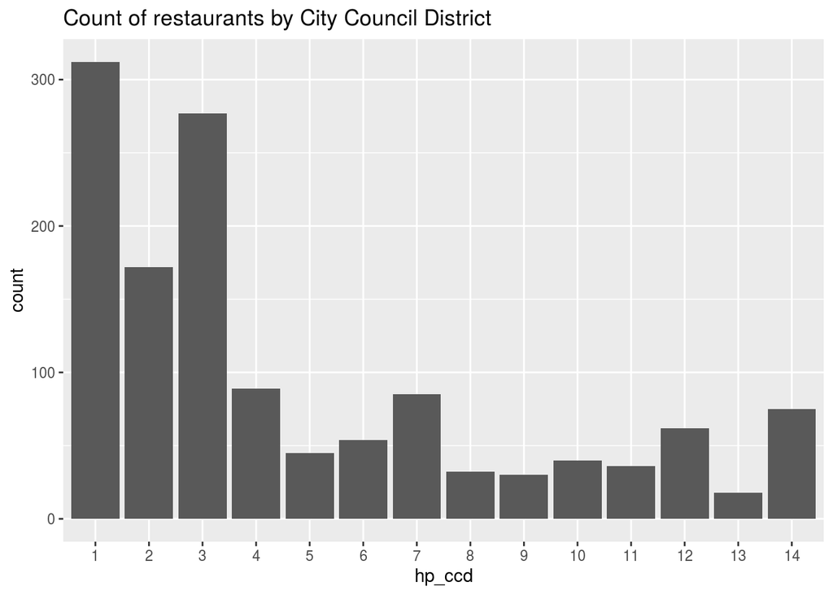

```r
ordered_ccds <- c("1","2","3","4","5","6","7","8","9","10","11","12","13","14")
all_restaurants$hp_ccd <- factor(all_restaurants$hp_ccd,labels=ordered_ccds)
all_restaurants %>% group_by(hp_ccd) %>% summarize(count=n()) %>% ggplot(aes(x=hp_ccd,y=count)) + geom_col() + ggtitle('Count of restaurants by City Council District')
```

## Part 2

Investigate the quantmod package.

```r
library('quantmod')
```

The quantmod package for R is designed to assist the quantitative trader in the development, testing, and deployment of statistically based trading models. It includes easy to use functions for fetching price data from Google, Yahoo, The Federal Reserve, and others. Although intended as a resource for packages that would automate trading, it can also be used to simple retrieve financial data.

Fetch historical stock data for Hewlett-Packard.

This function retrieves data into a special ‘xts’ object. The argument is the stock symbol, and the name of the resulting object is the same as that symbol. It is easy to create a data frame from the xts object.

```r
getSymbols('HPQ')
```

[output not shown]

```
## [1] "HPQ"
```

```r
hp_data = data.frame(HPQ)
str(hp_data)
```

```
## 'data.frame':    3198 obs. of  6 variables:
##  $ HPQ.Open    : num  18.6 18.8 18.9 19.2 19.1 ...
##  $ HPQ.High    : num  19 19 19.2 19.2 19.3 ...
##  $ HPQ.Low     : num  18.6 18.7 18.8 19 19 ...
##  $ HPQ.Close   : num  18.9 18.9 19.2 19.1 19.2 ...
##  $ HPQ.Volume  : num  46615800 26219600 38363900 25309500 26132600 ...
##  $ HPQ.Adjusted: num  14.5 14.5 14.7 14.6 14.7 ...
```

```r
summary(hp_data)
```

```
##     HPQ.Open         HPQ.High         HPQ.Low         HPQ.Close
##  Min.   : 5.286   Min.   : 5.477   Min.   : 5.154   Min.   : 5.318
##  1st Qu.:13.115   1st Qu.:13.248   1st Qu.:12.941   1st Qu.:13.098
##  Median :17.277   Median :17.507   Median :17.154   Median :17.341
##  Mean   :16.846   Mean   :17.048   Mean   :16.662   Mean   :16.859
##  3rd Qu.:20.831   3rd Qu.:21.106   3rd Qu.:20.649   3rd Qu.:20.854
##  Max.   :26.890   Max.   :27.080   Max.   :26.220   Max.   :26.420
##    HPQ.Volume         HPQ.Adjusted
##  Min.   :  3014800   Min.   : 4.341
##  1st Qu.: 14229175   1st Qu.:11.126
##  Median : 26987650   Median :14.335
##  Mean   : 30886302   Mean   :14.320
##  3rd Qu.: 39171350   3rd Qu.:17.135
##  Max.   :442012300   Max.   :25.586
```

One unfortunate quirk of the way these objects are named arises when a stock symbol is not simply alphanumeric. For instance, for Royal Dutch Shell, the stock symbol is RDS-A. This creates an object called RDS-A. It is difficult to do anything with this object, since R parses the name of the object as a subtraction of two other objects. I believe that quantmod has a way to use custom names, but it was not clear how to use it.

The quantmod package includes nice plotting functions. Plot price data using quantmod package

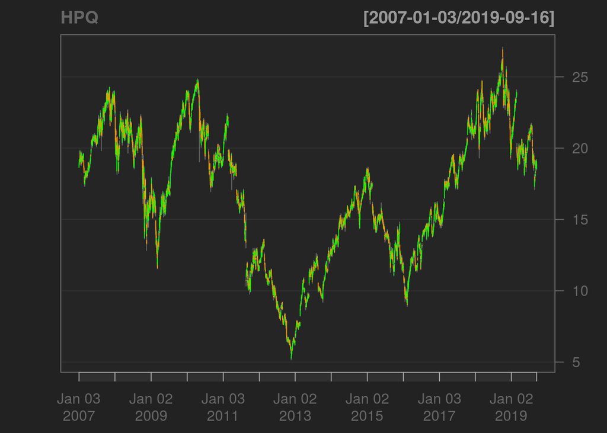

```r
chartSeries(HPQ, TA=NULL)
```

I would like to investigate how often HP stock closes on a high or on a low for the day. Also, compute the ‘closing percentage’ as a number between 0 and 1. Zero would mean it closes on the low for the day, 1 means it closes on the high for the day.

```r
hp_data <- hp_data %>%
  mutate(trade_range = HPQ.High - HPQ.Low) %>%
  mutate(price_range = HPQ.Close - HPQ.Open) %>%
  mutate(close_on_high = (HPQ.Close == HPQ.High)) %>%
  mutate(close_on_low  = (HPQ.Close == HPQ.Low)) %>%
  mutate(close_perc = (HPQ.Close - HPQ.Low)/trade_range)

hp_high_closes = sum(hp_data$close_on_high)
hp_low_closes = sum(hp_data$close_on_low)
hp_high_close_rate = 100*hp_high_closes/nrow(hp_data)
hp_low_close_rate = 100*hp_low_closes/nrow(hp_data)
```

Plot a histogram of the ‘closing percentage’

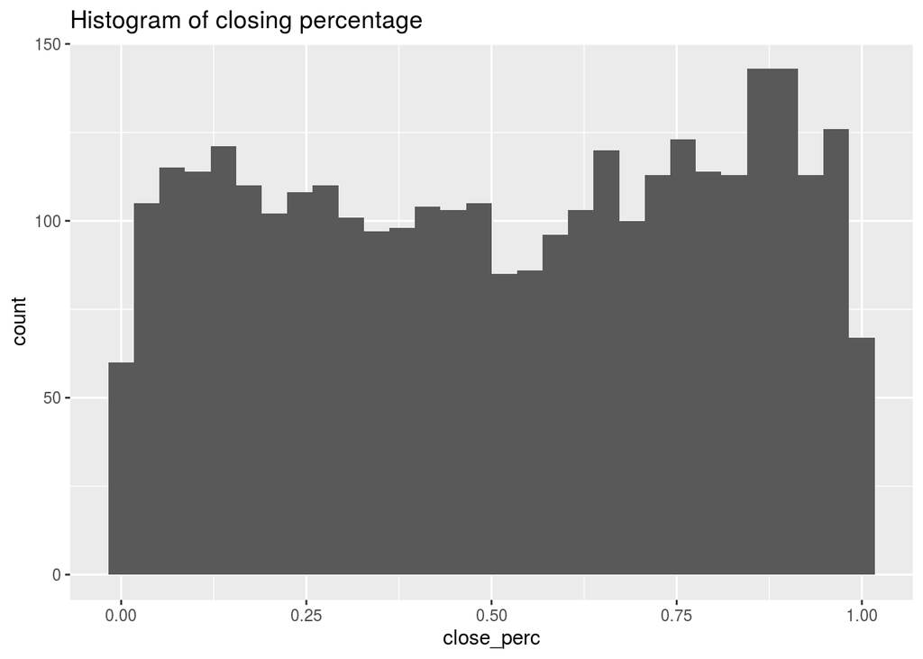

```r
hp_data %>% ggplot(aes(x=close_perc)) + geom_histogram() + ggtitle('Histogram of closing percentage')
```

From the bimodal distribution histogram, it seems that the closing price is likely to be close to the low for the day or to the high for the day. However, the stock closes exactly on a high only 1.5322076 percent of the time, and that it closes exactly on a low 1.3758599 percent of the time.

Look at a histogram of price ranges. Compare the size of ups with the size of the downs.

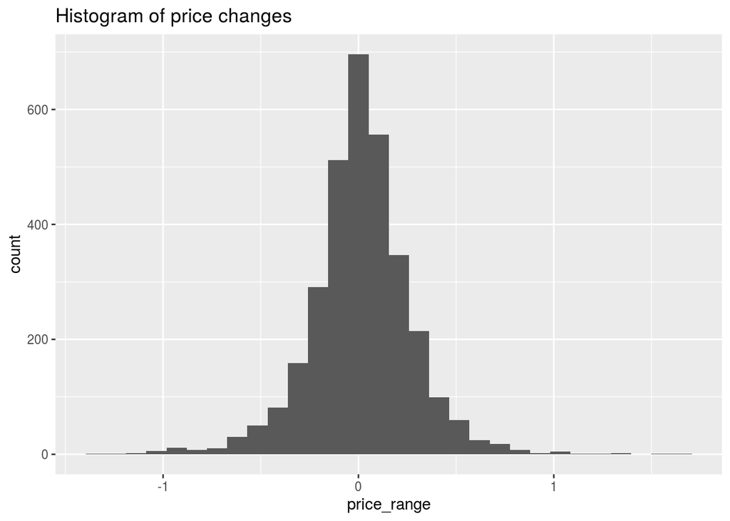

```r
hp_data %>% ggplot(aes(price_range)) + geom_histogram() + ggtitle('Histogram of price changes')
```

Look at a QQ plot of the price changes

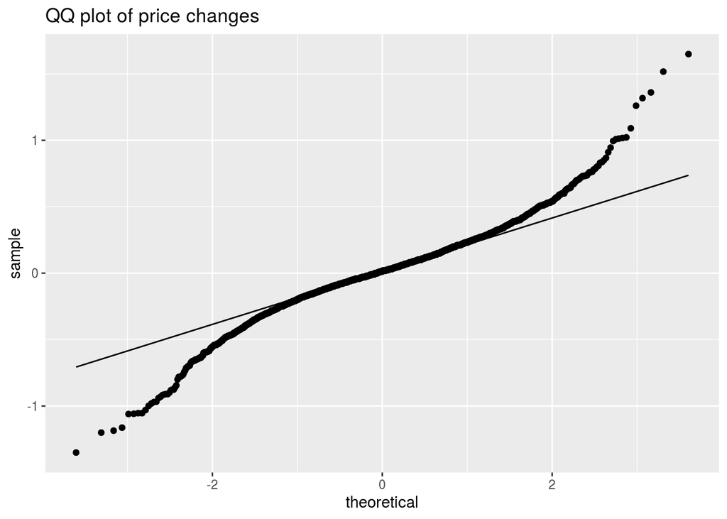

```r
hp_data %>% ggplot(aes(sample=price_range)) + stat_qq() + stat_qq_line() + ggtitle('QQ plot of price changes')
```

From the QQ plot and the histogram, it is clear that the price changes are not normally distributed, but have long tails. It would be interesting to understand why price changes have such extreme values.